**CSE2215** - Computer Graphics

Elmar Eisemann, Martin Skrodzki, Michael Weinmann, Ricardo Marroqium

# CSE2215 - Computer Graphics 2025-2026 - Assignment 5

In the previous assignment, you implemented the most fundamental part of a raytracer, that is, ray-triangle intersection tests. Further, you learned to construct and visualize rudimentary bounding volumes. In this assignment, we will now build upon this and add a more efficient method for intersection tests in large scenes comprising thousands of triangles denoted as **Bounding Volume Hierarchy** (BVH).

The camera is controlled in the same way as in the previous assignments. When you press `r` a ray is cast from the camera centre through the mouse cursor (along the camera’s *-z* axis). Keep in mind that because you are looking straight along the ray, the line may not be visible. *After clicking `r` try to move/rotate the camera to see the ray*. The program will test for intersections with all primitives in the scene using the BVH’s intersection method. Your task is to complete the BVH implementation in the file `bvh.cpp`. You do not need to modify any other file.

### Rules

For this assignment the following rules apply:

**General**

- We strongly recommend to do the assignment **individually**.
- This practical will help you prepare for the programming exam.
- We ask you to give the practical a try yourself to see whether you can solve it. Remember that the programming exam will also be an individual assessment.
- As always, you can approach the TAs with questions during the lab sessions.
- Your should compile your code **on Windows with Visual Studio 2022** (using the default MSVC toolchain). Otherwise, the TAs might not be able to help you with related issues.
- Submission on Brightspace is not required for this practical.

**Evaluation**

- This practical is ungraded.
- We provide you with a unit test framework using the [Catch2](https://github.com/catchorg/Catch2/) under `tests` for you to self-test your solutions.
- To run the interactive viewer, select and build the target `Bachelor_Assignment5`
- To use the test framework, select and build the target `Bachelor_Assignment5_Tests_Part1/2`
- Part 1 of the tests checks most individual methods and basic sanity of the compound methods.
- Only run the Part 2 tests once all Part 1 tests pass, as they rely on basic sanity of the BVH and might result in SEGFAULTS or unreadable error messages otherwise.
- You may add your own tests in ‘tests/your_tests.cpp’ and run them via the target `Bachelor_Assignment5_YourTests`
- If it prints “xxx failed”, it means some of your solutions are incorrect. See the error messages in the console for a detailed explanation.
- If it prints “All tests passed”, you are good to go!

# Framework information

The framework’s UI enables you to choose from a selection of test scenes to work with, including a custom scene (this initially loads a scene `custom.obj` from the data folder). If you like to load your own scene, you can simply overwrite the corresponding `custom.obj` with your own (please note that you should not rename your obj material file (`.mtl`), as the original filename is mentioned within the obj file itself).

### Ray

A ray is defined by its origin, a direction and a parameter *t* indicating the intersection point. In the code it is defined as follows:

```cpp
struct Ray {
    glm::vec3 origin { 0.0f };
    glm::vec3 direction { 0.0f, 0.0f, -1.0f };
    float t { std::numeric_limits<float>::max() };
};
```

### Scene (`scene.h`)

The Scene struct stores the scene type, meshes and lights for the provided test scenes. You can ignore lights and type for your BVH implementation. Only the scene’s meshes are relevant for you.

```cpp
struct Scene {
   std::vector<Mesh> meshes;
   // ...
};
```

Each Mesh contains vertices and triangles defined on these vertices. The triangles are defined by the indices of their vertices:

```cpp
struct Mesh {
   std::vector<Vertex> vertices;
   std::vector<glm::uvec3> triangles;

   Material material;
};
```

The vertices define the position and normal vector of the vertex. Further each mesh has a material, containing the material information required for the shading (relevant are only kd, ks and shininess):

```cpp
struct Vertex {
   glm::vec3 position;
   glm::vec3 normal;
   //...
};
struct Material {
   glm::vec3 kd; // Diffuse color
   glm::vec3 ks{ 0.0f }; // Specular color
   float shininess{ 1.0f };
   //...
};
```

### Intersection (`intersect.h`)

The triangle intersection tests you previously implemented are provided. By default, as for the tests, the framework links against a prebuilt reference solution.

```cpp
bool intersectRayWithTriangle(const glm::vec3& v0, const glm::vec3& v1, const glm::vec3& v2, Ray& ray)
```

### HitData & AABB (`common.h`)

In `common.h` we define some basic data structures used throughout the application. The ones relevant to you are the HitData, containing the shading information of a hit point, and the AxisAlignedBox used for the BVH:

```cpp
struct HitData {
   glm::vec3 normal;
   Material material;
};
struct AxisAlignedBox {
   glm::vec3 lower { 0.0f };
   glm::vec3 upper { 1.0f };
};
```

### Draw

In `draw.h/cpp` we define methods to draw the scene, most of them you can safely ignore. However, if you choose to implement a visual debug, you might be interested in the method:

```cpp
void drawAABB(const AxisAlignedBox& box, DrawMode drawMode = DrawMode::Filled, const glm::vec3& color = glm::vec3(1.0f), float transparency = 1.0f);
```

## Acceleration data structure

The acceleration data structure will allow you to render large scenes in a reasonable amount of time. For the BVH implementation in the scope of this assignment, you will use **Axis-Aligned Bounding Boxes** (AABBs) (as seen in the lecture) and a binary tree such that every parent node has two children.

`BVHInterface`, defined in `bvh_interface.h`, describes an acceleration structure to which your own acceleration structure implementation must conform. The unit tests check your implementation against this interface, and it is used throughout the framework to abstract away your implementation and test individual components. `BVHInterface` allows you to run intersection tests against the entire scene, and returns information about ray hits in a `HitData` object.

You should not to modify this interface, but you should certainly read it! If you modify the interface, you will likely break the unit tests. We recommend you understand how the interface’s `Primitive` and `Node` objects allow for a compact representation of the scene’s meshes, as you’ll be interacting with them in your own implementation.

Further there is a header file `bvh.h` providing you the structure for your code, we also recommend carefully reading this file, and once more you should not modify it.

You implement your acceleration structure solely in `bvh.cpp`.

*Hint*: You might not always need all parameters of a method in order to correctly implement it.  
*Hint*: The comments in the code provide additional information and more detailed instructions for the individual methods.

### 1. Compute Bounding Boxes

First you need to implement the methods to obtain axis-aligned bounding boxes around a primitive:

```cpp
AxisAlignedBox computePrimitiveAABB(const BVHInterface::Primitive primitive)
```

or a range of primitives:

```cpp
AxisAlignedBox computeSpanAABB(std::span<const BVHInterface::Primitive> primitives)
```

### 2. Bounding Volume Split

Before you can recursively construct a BVH, you need methods for subdividing axis-aligned bounding boxes. Further, the subdivision should be conducted at reasonable (efficient) splitting positions.

Implement the following method to determine the geometric centroid of a triangle:

```cpp
glm::vec3 computePrimitiveCentroid(const BVHInterface::Primitive primitive)
```

Next, implement a method to determine the longest axis of an AABB, since it might be a good axis to subdivide:

```cpp
uint32_t computeAABBLongestAxis(const AxisAlignedBox& aabb)
```

Finally, given a range of BVH triangles, sort these along a specified axis based on their geometric centroid. Then, find and return the split index in the range, such that the subrange containing the first element of the list is at least as big as the other, and both differ at most by one element in size:

```cpp
size_t splitPrimitivesByMedian(const AxisAlignedBox& aabb, uint32_t axis, std::span<BVHInterface::Primitive> primitives)
```

### 3. Recursive BVH Construction

We have almost all tools ready to recursively build a BVH, but two puzzle pieces are still missing.

Implement a helper method to instantiate Node objects as a leaf node:

```cpp
BVH::Node BVH::buildLeafData(const Scene& scene, const AxisAlignedBox& aabb, std::span<Primitive> primitives)
```

Further, implement a helper method to instantiate Node objects as a parent with two children:

```cpp
BVH::Node BVH::buildNodeData(const Scene& scene, const AxisAlignedBox& aabb, uint32_t leftChildIndex, uint32_t rightChildIndex)
```

You are now ready to recursively construct a BVH hierarchy based on the priorly implemented methods:

```cpp
void BVH::buildRecursive(const Scene& scene, std::span<Primitive> primitives, uint32_t nodeIndex)
```

*Note*: The unit tests for the two helper methods not only isolatedly test those methods but also their usage during the recursive build.

### 4. BVH Traversal

Now that we built the acceleration structure, we want to use it for faster intersection tests. Implement the hierarchy traversal routine, called by the BVH’s intersect(). Intersect a ray with the BVH and its primitives, and update `hitInfo` accordingly.

*Note*: We cannot unit test if you actually use your BVH to traverse with a better runtime complexity. We can only unit test if your traversal still leads to correct intersections. So with the default (naive) intersection method the traversal test is expected to pass. Make sure it still does, after you implemented the smarter intersection routine.

```cpp
bool intersectRayWithBVH(const Scene& scene, const BVHInterface& bvh, Ray& ray, HitData& hitInfo)
```

### Visual debug

To ease and verify your implementation we recommend you to implement a visual debug as follows: - Visualize one level of the BVH’s hierarchy at a time by drawing the hierarchy’s respective AABBs - Visualize one leaf node at a time including its contained triangles.

This can help you verify correctness to some extent. To facilitate this, you may want to implement the following methods: - `bvh.buildNumLevels(...)/buildNumLeaves(...)` - Helper functions to count the nr. of levels and leaves, called by the BVH’s constructor. These should fill in `m_numLevels/m_numLeaves`. - `bvh.debugDrawLevel(...)/debugDrawLeaf(...)` - Draw bounding boxes or leaf data. These are controlled from the UI by default.

### Example renders

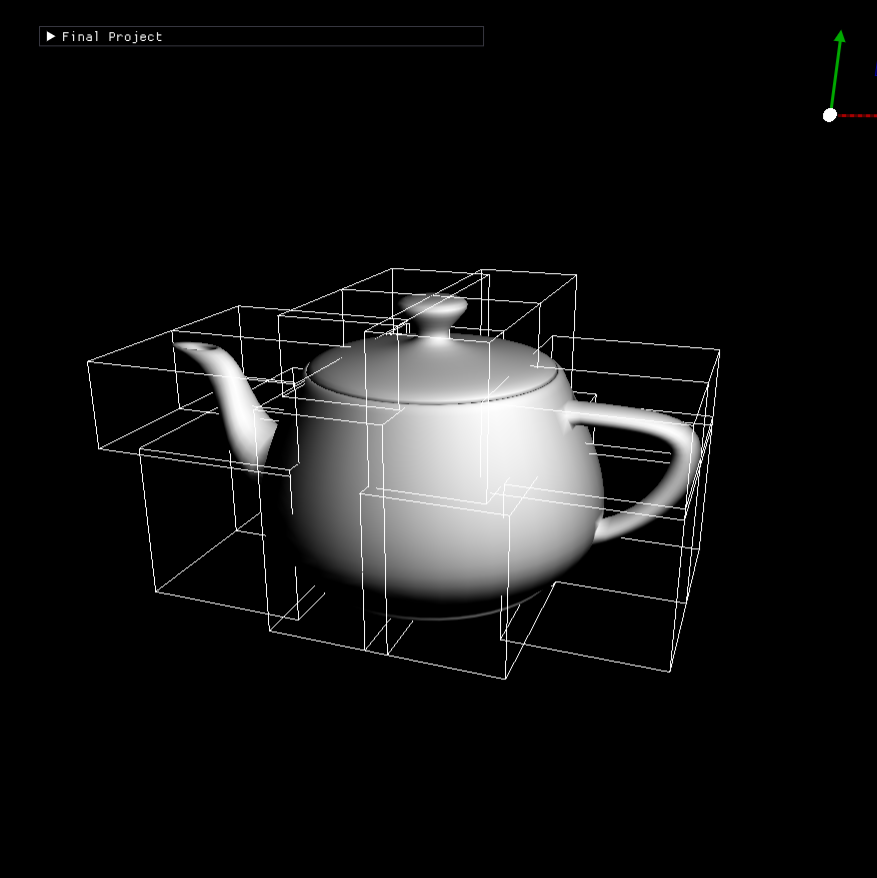

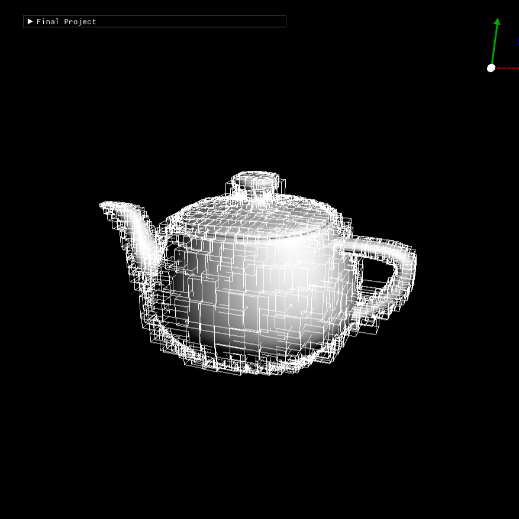